# Tugas Pertemuan 6 (Pemodelan ARIMA - Pendugaan Parameter, Diagnostik Model, dan Peramalan)

Qurrota A’yunina | M0401241049

26 September 2026

## Packages

```r
library(ggplot2)
library(tsibble)
library(tseries)
library(MASS)
library(forecast)
library(TSA)
library(TTR)
library(aTSA)
library(graphics)
library(readxl)
```

## Data

### Impor Data

```r
# 1. Impor data dari file Excel
data_sepeda <- read_excel("C://Users//USER//OneDrive//ドキュメント//Mata Kuliah Semester 5//Metode Peramalan Deret Waktu//Data Penyewaan Sepeda (Day) Time Series.xlsx")

# 2. Ubah kolom 'cnt' menjadi objek time series (ts)
data_ts <- ts(data_sepeda$cnt)

# 3. Pembagian Data Latih (Train) dan Data Uji (Test) 80:20
n <- length(data_ts)
n_train <- round(0.80 * n)

data.train <- data_ts[1:n_train]
data.test  <- data_ts[(n_train + 1):n]

# 4. Menampilkan informasi hasil pembagian
cat("Total seluruh data :", n, "baris\n")
```

```
## Total seluruh data : 731 baris
```

```r
cat("Jumlah data latih  :", length(data.train), "baris (80%)\n")
```

```
## Jumlah data latih  : 585 baris (80%)
```

```r
cat("Jumlah data uji    :", length(data.test), "baris (20%)\n")
```

```
## Jumlah data uji    : 146 baris (20%)
```

## Eksplorasi Data

### Plot Data Penuh

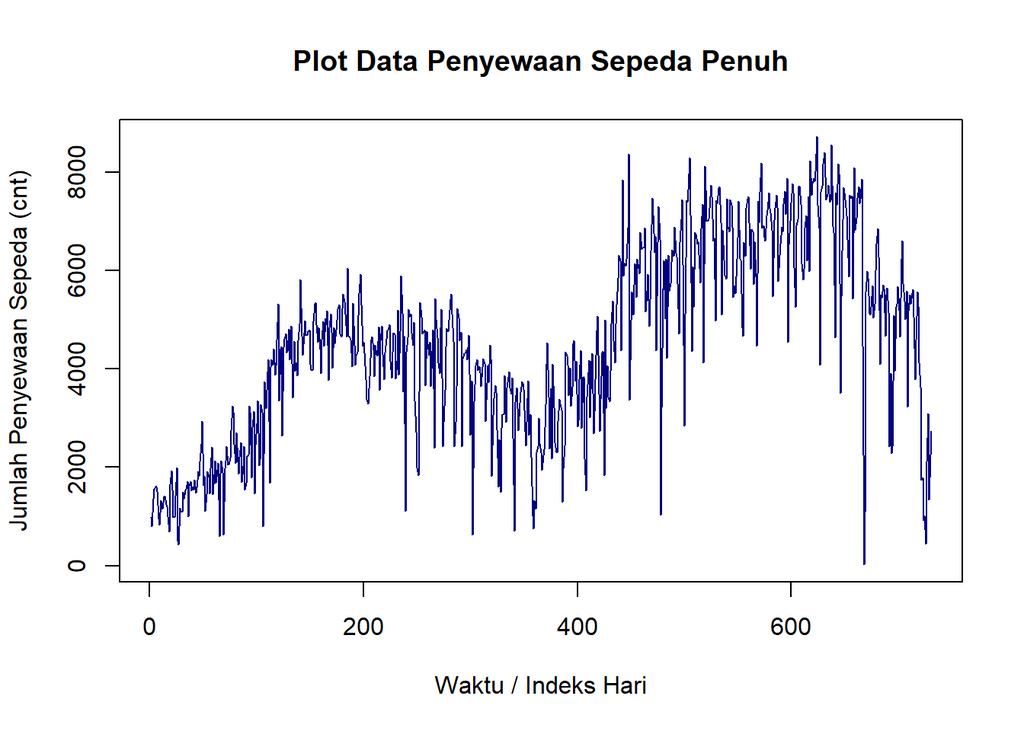

```r
# Plot seluruh data time series (cnt)
plot.ts(data_ts,
        lty = 1,
        col = "navyblue",
        xlab = "Waktu / Indeks Hari",
        ylab = "Jumlah Penyewaan Sepeda (cnt)",
        main = "Plot Data Penyewaan Sepeda Penuh")
```

Berdasarkan plot data deret waktu di atas, terlihat bahwa data penyewaan sepeda secara keseluruhan memiliki kecenderungan tren yang meningkat (*upward trend*) serta fluktuasi/pola musiman. Jumlah penyewaan sepeda mengalami peningkatan secara bertahap dari periode awal (indeks hari 0 hingga sekitar 200), kemudian mengalami penurunan di pertengahan waktu (indeks hari 300–400), dan kembali melonjak hingga mencapai puncaknya (melebihi 6.000 penyewaan) pada indeks hari 400–600 sebelum akhirnya sedikit menurun di bagian akhir periode observasi. Berdasarkan pola data tersebut, pembagian data latih (*training data*) dan data uji (*testing data*) ditetapkan dengan proporsi **80% : 20%**.

### Plot Data Latih

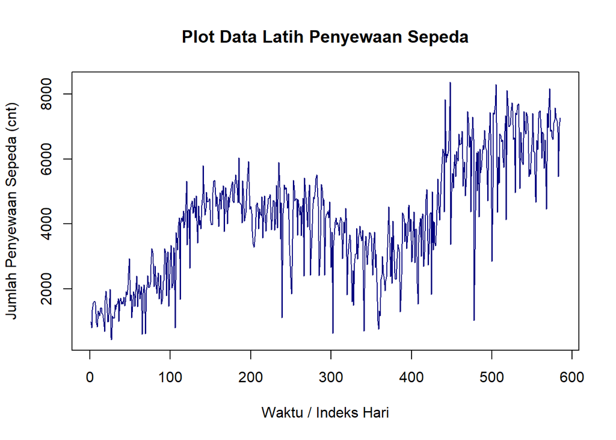

```r
# Plot data latih penyewaan sepeda
plot.ts(data.train,
        lty = 1,
        col = "navyblue",
        xlab = "Waktu / Indeks Hari",
        ylab = "Jumlah Penyewaan Sepeda (cnt)",
        main = "Plot Data Latih Penyewaan Sepeda")
```

Berdasarkan plot data deret waktu pada data latih di atas, terlihat bahwa data penyewaan sepeda cenderung memiliki tren yang meningkat secara keseluruhan dan tidak bergerak di sekitar nilai tengah (*mean*) tertentu. Pergerakan data diawali dengan tren naik dari indeks waktu 0 hingga sekitar 200, mengalami penurunan pada periode pertengahan (indeks 300–400), lalu mengalami peningkatan signifikan hingga mencapai nilai di atas 8.000 pada indeks waktu setelah 400. Pola ini mengindikasikan secara visual bahwa data latih **belum stasioner dalam rataan**.

### Plot Data Uji

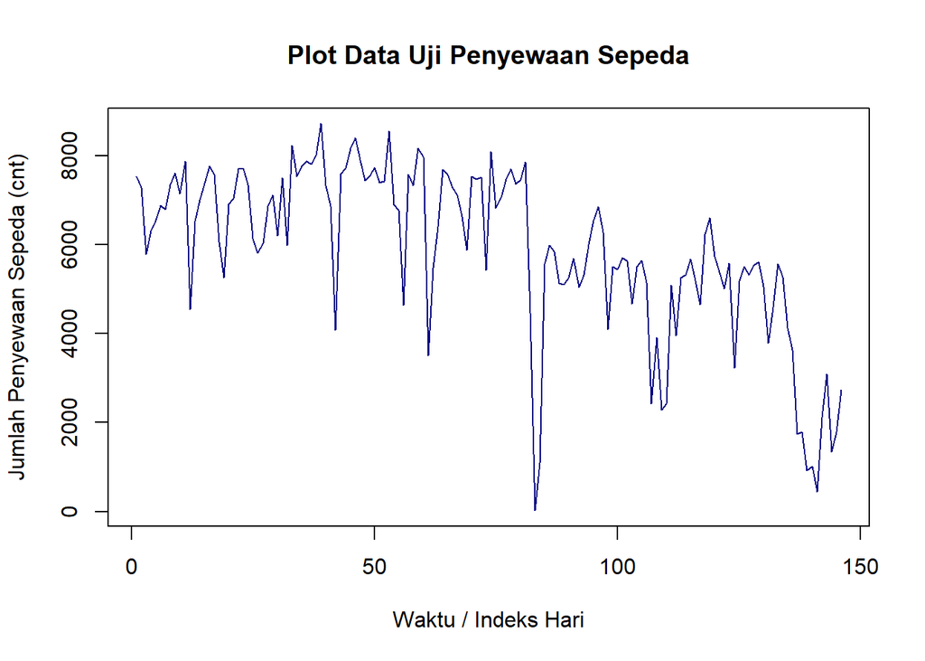

```r
# Plot data uji penyewaan sepeda
plot.ts(data.test,
        lty = 1,
        col = "navyblue",
        xlab = "Waktu / Indeks Hari",
        ylab = "Jumlah Penyewaan Sepeda (cnt)",
        main = "Plot Data Uji Penyewaan Sepeda")
```

Berdasarkan plot data uji di atas, terlihat gambaran pergerakan jumlah penyewaan sepeda pada 20% periode akhir pengamatan (sekitar 146 observasi harian). Pola data uji diawali dengan fluktuasi yang relatif tinggi pada kisaran nilai 6.000 hingga mendekati 8.000 penyewaan, sempat mengalami penurunan tajam yang signifikan pada sekitar indeks hari ke-80, lalu cenderung menunjukkan pola tren menurun hingga bagian akhir periode data. Data uji ini disisihkan dan tidak digunakan dalam proses identifikasi maupun estimasi parameter model, melainkan murni diperuntukkan bagi tahap evaluasi akurasi hasil peramalan (*out-of-sample forecasting*) model ARIMA terbaik nantinya.

## Uji Stasioneritas Data

### Plot ACF

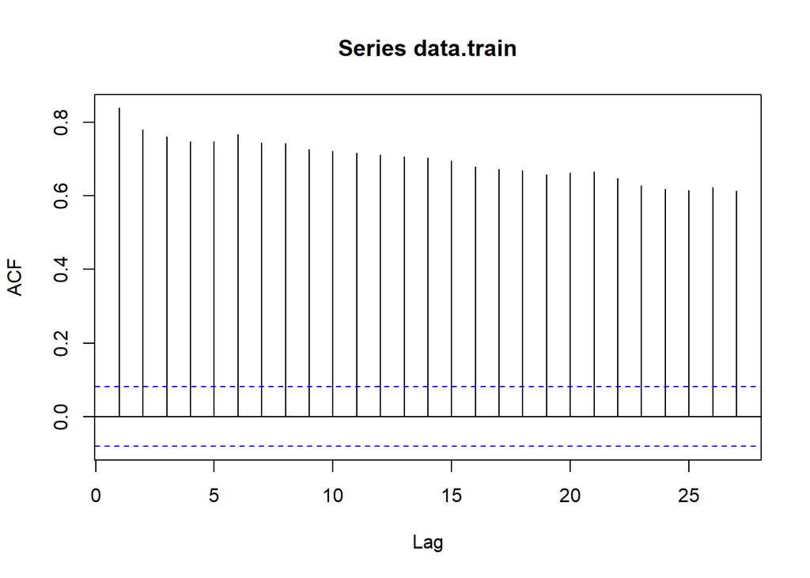

```r
acf(data.train)
```

Berdasarkan plot ACF di atas, terlihat bahwa nilai autokorelasi meluruh atau menurun secara sangat perlahan (*slowly tailing off*) dan nilainya masih berada jauh di luar garis batas selang kepercayaan (garis biru putus-putus) bahkan hingga *lag* yang tinggi (*lag* ke-25 lebih). Pola meluruh lambat pada plot ACF ini mengonfirmasi bahwa data latih penyewaan sepeda **belum stasioner dalam rataan**. Oleh karena itu, data memerlukan proses pembedaan (*differencing*) pada tahap berikutnya agar diperoleh data yang stasioner dalam rataan.

### Uji ADF

```r
tseries::adf.test(data.train)
```

```
##
##  Augmented Dickey-Fuller Test
##
## data:  data.train
## Dickey-Fuller = -2.6064, Lag order = 8, p-value = 0.3216
## alternative hypothesis: stationary
```

$H_0$ : Data tidak stasioner dalam rataan

$H_1$ : Data stasioner dalam rataan

Berdasarkan uji ADF tersebut, didapat *p-value* sebesar 0.3216 yang lebih besar dari taraf nyata 5% sehingga tak tolak $H_0$ dan menandakan bahwa data tidak stasioner dalam rataan. Hal ini sesuai dengan hasil eksplorasi menggunakan plot time series dan plot ACF, sehingga ketidakstasioneran model kedepannya harus ditangani.

### Plot Box-Cox

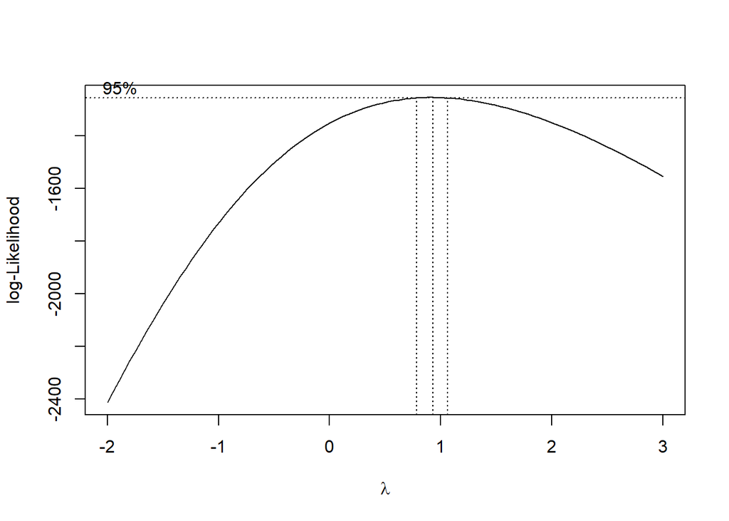

```r
#--CEK KESTASIONERAN RAGAM (BOX-COX)--#
library(MASS)

# Buat indeks berdasarkan panjang data latih
index <- seq_len(length(data.train))

# Uji Box-Cox
bc <- boxcox(
  data.train ~ index,
  lambda = seq(-2, 3, by = 0.1)
)
```

```r
# Nilai lambda optimum
lambda <- bc$x[which.max(bc$y)]
cat("Lambda optimum:", lambda, "\n")
```

```
## Lambda optimum: 0.9292929
```

```r
# Selang kepercayaan 95% untuk lambda
ci_lambda <- bc$x[bc$y > max(bc$y) - 0.5 * qchisq(0.95, 1)]

# Batas bawah dan batas atas
ci_lower <- min(ci_lambda)
ci_upper <- max(ci_lambda)

c(Batas_Bawah = ci_lower, Batas_Atas = ci_upper)
```

```
## Batas_Bawah  Batas_Atas
##   0.8282828   1.0303030
```

Gambar di atas menunjukkan nilai $\lambda$ optimum sebesar **0,93** (atau 0,929) dan pada selang kepercayaan 95% nilai $\lambda$ memiliki batas bawah **0,83** (atau 0,828) dan batas atas **1,03** (atau 1,030). Karena selang kepercayaan tersebut **memuat nilai satu** ($\lambda = 1$), maka dapat disimpulkan bahwa data latih **stasioner dalam ragam** dan tidak memerlukan proses transformasi.

## Penanganan Ketidakstasioneran Data

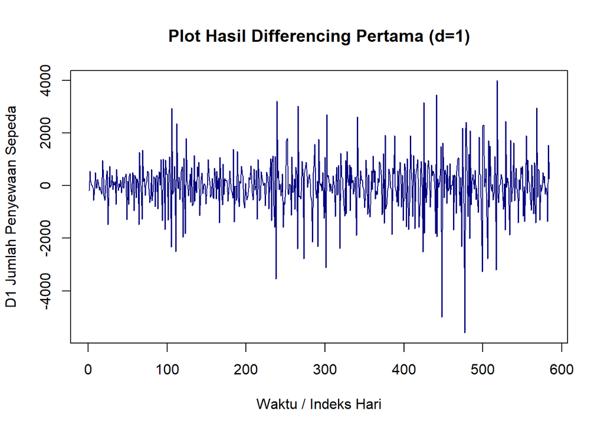

```r
# 1. Differencing pertama pada data latih
data.train.diff <- diff(data.train, differences = 1)

# 2. Plot hasil differencing
plot.ts(data.train.diff,
        lty = 1,
        col = "navyblue",
        xlab = "Waktu / Indeks Hari",
        ylab = "D1 Jumlah Penyewaan Sepeda",
        main = "Plot Hasil Differencing Pertama (d=1)")
```

Berdasarkan plot deret waktu hasil diferensiasi tingkat pertama ($d=1$) di atas, terlihat bahwa data kini sudah bergerak secara acak memotong nilai tengah sekitar nol ($0$) dan pola tren naik-turun yang sebelumnya ada sudah hilang. Selain itu, lebar pita/fluktuasi data secara umum relatif stabil sepanjang periode waktu (0 hingga 585). Pola ini mengindikasikan secara visual bahwa data latih penyewaan sepeda **sudah stasioner dalam rataan**. Selanjutnya, kestasioneran ini akan dikonfirmasi secara formal melalui plot ACF dan uji Augmented Dickey-Fuller (ADF) pada data hasil diferensiasi.

### Plot ACF

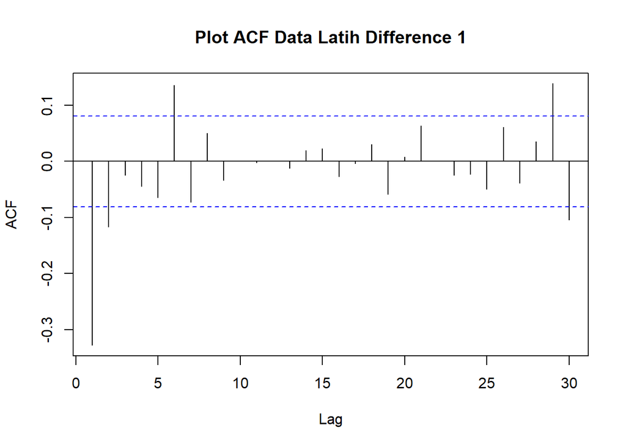

```r
acf(data.train.diff, main = "Plot ACF Data Latih Difference 1", lag.max = 30)
```

Berdasarkan plot ACF dari data latih hasil pembedaan pertama ($d=1$) di atas, terlihat bahwa nilai autokorelasi tidak lagi meluruh secara perlahan (*slowly tailing off*), melainkan langsung turun dan berada di sekitar nilai nol. Sebagian besar garis *lag* berada di dalam selang kepercayaan (garis biru putus-putus). Pola ini mengonfirmasi secara visual bahwa data latih **sudah stasioner dalam rataan** setelah dilakukan *differencing* orde 1 ($d=1$).

### Uji ADF

```r
tseries::adf.test(data.train.diff)
```

```
##
##  Augmented Dickey-Fuller Test
##
## data:  data.train.diff
## Dickey-Fuller = -12.874, Lag order = 8, p-value = 0.01
## alternative hypothesis: stationary
```

$H_0$ : Data tidak stasioner dalam rataan

$H_1$ : Data stasioner dalam rataan

Berdasarkan uji ADF tersebut, didapat *p-value* sebesar 0.01 yang lebih kecil dari taraf nyata 5% sehingga tolak $H_0$ atau data stasioner dalam rataan. Hal ini sesuai dengan hasil eksplorasi menggunakan plot time series dan plot ACF, sehingga dalam hal ini ketidakstasioneran data sudah berhasil ditangani dan dapat dilanjutkan ke pemodelan.

## Identifikasi Model

### Plot ACF

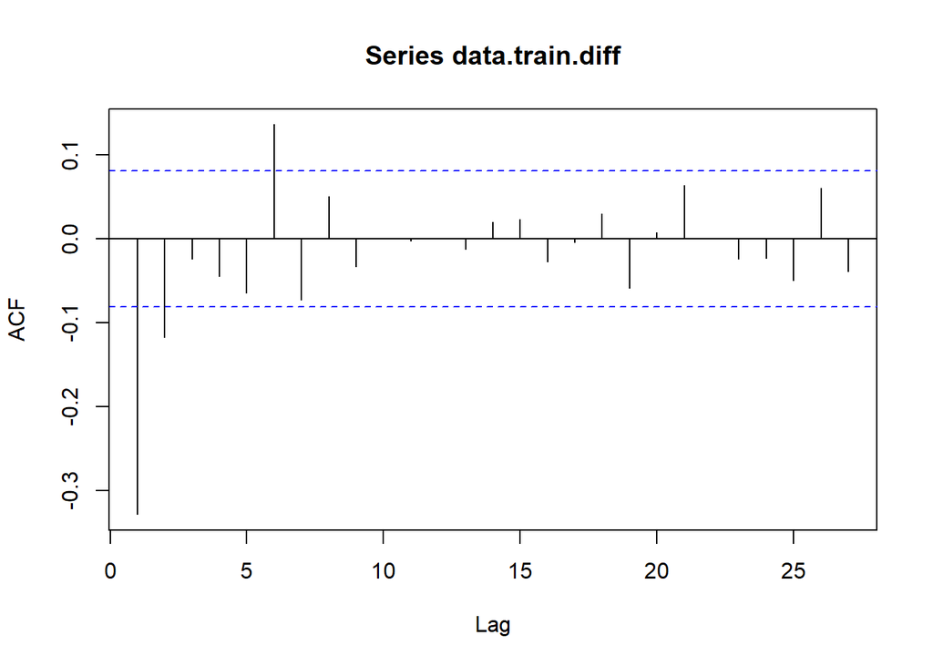

```r
acf(data.train.diff)
```

Berdasarkan plot tersebut, terlihat bahwa plot ACF cenderung *cuts off* pada lag ke-1 (dan lag ke-2), sehingga jika plot PACF dianggap *tails off*, maka model tentatifnya adalah **ARIMA(0,1,1)** dan **ARIMA(0,1,2)**.

### Plot PACF

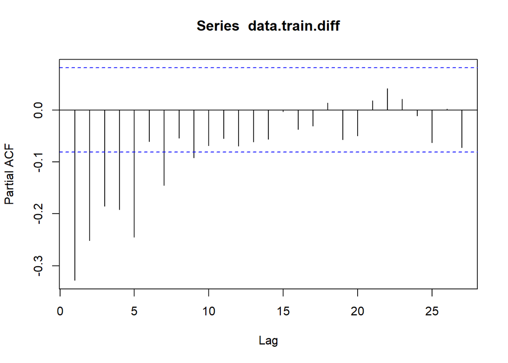

```r
pacf(data.train.diff)
```

Berdasarkan plot tersebut, terlihat bahwa plot PACF cenderung *tails off* (meluruh secara perlahan). Namun, jika diposisikan *cuts off* pada lag ke-1 atau lag ke-2, maka model tentatifnya adalah **ARIMA(1,1,0)** dan **ARIMA(2,1,0)**.

Jika baik plot ACF maupun plot PACF keduanya dianggap *tails off*, maka model tentatif yang terbentuk adalah **ARIMA(1,1,1)**.

### Plot EACF

```r
eacf(data.train.diff)
```

```
## AR/MA
##   0 1 2 3 4 5 6 7 8 9 10 11 12 13
## 0 x x o o o x o o o o o  o  o  o
## 1 x o o o o x o o o o o  o  o  o
## 2 x x o o o x o o o o o  o  o  o
## 3 x x x o x x o o o o o  o  o  o
## 4 x x x x x o o o o o o  o  o  o
## 5 x x x o x x o o o o o  o  o  o
## 6 x x o o x o o o o o o  o  o  o
## 7 x x o x o o o o o o o  o  o  o
```

Identifikasi model menggunakan plot EACF dilakukan dengan melihat sudut kiri atas dari pola segitiga angka nol (`o`). Dalam hal ini, model tentatif yang terbentuk adalah **ARIMA(0,1,2)**, **ARIMA(1,1,2)**, dan **ARIMA(2,1,2)**.

Sehingga gabungan seluruh kandidat model tentatif yang akan diestimasi parameternya pada tahap berikutnya adalah:

1. **ARIMA(0,1,1)**
2. **ARIMA(0,1,2)**
3. **ARIMA(1,1,0)**
4. **ARIMA(2,1,0)**
5. **ARIMA(1,1,1)**
6. **ARIMA(1,1,2)**
7. **ARIMA(2,1,2)**

## Pendugaan Parameter Model Tentatif

### ARIMA(0,1,1)

```r
model1.da=Arima(data.train.diff, order=c(0,0,1),method="ML")
summary(model1.da)
```

```
## Series: data.train.diff
## ARIMA(0,0,1) with non-zero mean
##
## Coefficients:
##           ma1    mean
##       -0.8179  9.8661
## s.e.   0.0319  6.5991
##
## sigma^2 = 757939:  log likelihood = -4781.41
## AIC=9568.82   AICc=9568.87   BIC=9581.93
##
## Training set error measures:
##                     ME     RMSE      MAE      MPE     MAPE      MASE      ACF1
## Training set 0.8878889 869.1051 631.8617 190.6823 315.9918 0.5713886 0.2087663
```

```r
lmtest::coeftest(model1.da)
```

```
##
## z test of coefficients:
##
##            Estimate Std. Error  z value Pr(>|z|)
## ma1       -0.817925   0.031928 -25.6178   <2e-16 ***
## intercept  9.866077   6.599110   1.4951   0.1349
## ---
## Signif. codes:  0 '***' 0.001 '**' 0.01 '*' 0.05 '.' 0.1 ' ' 1
```

### ARIMA (0,1,2)

```r
model2.da=Arima(data.train.diff, order=c(0,0,2),method="ML")
summary(model2.da)
```

```
## Series: data.train.diff
## ARIMA(0,0,2) with non-zero mean
##
## Coefficients:
##           ma1      ma2    mean
##       -0.6163  -0.2364  9.9047
## s.e.   0.0387   0.0376  5.2026
##
## sigma^2 = 713334:  log likelihood = -4763.23
## AIC=9534.46   AICc=9534.53   BIC=9551.94
##
## Training set error measures:
##                     ME     RMSE      MAE     MPE     MAPE      MASE        ACF1
## Training set 0.5638566 842.4189 600.0319 168.646 250.7551 0.5426051 0.009464469
```

```r
lmtest::coeftest(model2.da)
```

```
##
## z test of coefficients:
##
##            Estimate Std. Error  z value  Pr(>|z|)
## ma1       -0.616286   0.038668 -15.9378 < 2.2e-16 ***
## ma2       -0.236371   0.037599  -6.2866 3.245e-10 ***
## intercept  9.904690   5.202600   1.9038   0.05694 .
## ---
## Signif. codes:  0 '***' 0.001 '**' 0.01 '*' 0.05 '.' 0.1 ' ' 1
```

### ARIMA (1,1,0)

```r
model3.da=Arima(data.train.diff, order=c(1,0,0),method="ML")
summary(model3.da)
```

```
## Series: data.train.diff
## ARIMA(1,0,0) with non-zero mean
##
## Coefficients:
##           ar1     mean
##       -0.3274  10.7472
## s.e.   0.0391  29.5005
##
## sigma^2 = 897869:  log likelihood = -4830.39
## AIC=9666.77   AICc=9666.81   BIC=9679.88
##
## Training set error measures:
##                       ME     RMSE      MAE      MPE     MAPE      MASE
## Training set -0.09493776 945.9354 677.2106 129.3724 232.7262 0.6123973
##                     ACF1
## Training set -0.08291204
```

```r
lmtest::coeftest(model3.da)
```

```
##
## z test of coefficients:
##
##            Estimate Std. Error z value Pr(>|z|)
## ar1       -0.327423   0.039067 -8.3811   <2e-16 ***
## intercept 10.747216  29.500490  0.3643   0.7156
## ---
## Signif. codes:  0 '***' 0.001 '**' 0.01 '*' 0.05 '.' 0.1 ' ' 1
```

### ARIMA (2,1,0)

```r
model4.da=Arima(data.train.diff, order=c(2,0,0),method="ML")
summary(model4.da)
```

```
## Series: data.train.diff
## ARIMA(2,0,0) with non-zero mean
##
## Coefficients:
##           ar1      ar2     mean
##       -0.4103  -0.2521  10.2252
## s.e.   0.0400   0.0401  22.8050
##
## sigma^2 = 842169:  log likelihood = -4811.25
## AIC=9630.5   AICc=9630.57   BIC=9647.98
##
## Training set error measures:
##                       ME     RMSE      MAE      MPE     MAPE      MASE
## Training set -0.01700588 915.3374 655.4956 87.22646 257.7345 0.5927605
##                     ACF1
## Training set -0.04725522
```

```r
lmtest::coeftest(model4.da)
```

```
##
## z test of coefficients:
##
##            Estimate Std. Error  z value  Pr(>|z|)
## ar1       -0.410338   0.040050 -10.2457 < 2.2e-16 ***
## ar2       -0.252141   0.040087  -6.2898 3.178e-10 ***
## intercept 10.225203  22.805022   0.4484    0.6539
## ---
## Signif. codes:  0 '***' 0.001 '**' 0.01 '*' 0.05 '.' 0.1 ' ' 1
```

### ARIMA (1,1,1)

```r
model5.da=Arima(data.train.diff, order=c(1,0,1),method="ML")
summary(model5.da)
```

```
## Series: data.train.diff
## ARIMA(1,0,1) with non-zero mean
##
## Coefficients:
##          ar1      ma1    mean
##       0.2826  -0.8979  9.9293
## s.e.  0.0456   0.0184  5.0326
##
## sigma^2 = 713262:  log likelihood = -4763.19
## AIC=9534.37   AICc=9534.44   BIC=9551.85
##
## Training set error measures:
##                     ME     RMSE     MAE      MPE     MAPE      MASE       ACF1
## Training set 0.5263043 842.3767 599.993 174.9354 259.2064 0.5425699 0.01029056
```

```r
lmtest::coeftest(model5.da)
```

```
##
## z test of coefficients:
##
##            Estimate Std. Error  z value  Pr(>|z|)
## ar1        0.282616   0.045620   6.1949 5.831e-10 ***
## ma1       -0.897930   0.018408 -48.7803 < 2.2e-16 ***
## intercept  9.929327   5.032575   1.9730   0.04849 *
## ---
## Signif. codes:  0 '***' 0.001 '**' 0.01 '*' 0.05 '.' 0.1 ' ' 1
```

### ARIMA (1,1,2)

```r
model6.da=Arima(data.train.diff, order=c(1,0,2),method="ML")
summary(model6.da)
```

```
## Series: data.train.diff
## ARIMA(1,0,2) with non-zero mean
##
## Coefficients:
##          ar1      ma1      ma2    mean
##       0.1529  -0.7590  -0.1191  9.9043
## s.e.  0.1514   0.1508   0.1270  5.0854
##
## sigma^2 = 713402:  log likelihood = -4762.75
## AIC=9535.5   AICc=9535.6   BIC=9557.35
##
## Training set error measures:
##                     ME     RMSE      MAE      MPE     MAPE      MASE
## Training set 0.6279067 841.7339 598.6214 172.0225 253.1689 0.5413296
##                       ACF1
## Training set -6.720075e-05
```

```r
lmtest::coeftest(model6.da)
```

```
##
## z test of coefficients:
##
##           Estimate Std. Error z value Pr(>|z|)
## ar1        0.15287    0.15144  1.0094  0.31277
## ma1       -0.75895    0.15080 -5.0330 4.83e-07 ***
## ma2       -0.11907    0.12705 -0.9372  0.34864
## intercept  9.90433    5.08542  1.9476  0.05146 .
## ---
## Signif. codes:  0 '***' 0.001 '**' 0.01 '*' 0.05 '.' 0.1 ' ' 1
```

### ARIMA (2,1,2)

```r
model7.da=Arima(data.train.diff, order=c(2,0,2),method="ML")
summary(model7.da)
```

```
## Series: data.train.diff
## ARIMA(2,0,2) with non-zero mean
##
## Coefficients:
##          ar1      ar2      ma1     ma2    mean
##       1.1548  -0.2967  -1.7646  0.7888  9.9675
## s.e.  0.1500   0.0526   0.1491  0.1325  5.9634
##
## sigma^2 = 710618:  log likelihood = -4761.15
## AIC=9534.29   AICc=9534.44   BIC=9560.51
##
## Training set error measures:
##                     ME     RMSE     MAE      MPE     MAPE      MASE
## Training set 0.8513589 839.3652 596.769 156.3758 247.3698 0.5396545
##                      ACF1
## Training set -0.001289266
```

```r
lmtest::coeftest(model7.da)
```

```
##
## z test of coefficients:
##
##           Estimate Std. Error  z value  Pr(>|z|)
## ar1        1.15481    0.14997   7.7005 1.355e-14 ***
## ar2       -0.29671    0.05264  -5.6366 1.735e-08 ***
## ma1       -1.76457    0.14913 -11.8321 < 2.2e-16 ***
## ma2        0.78877    0.13248   5.9539 2.619e-09 ***
## intercept  9.96751    5.96342   1.6714   0.09463 .
## ---
## Signif. codes:  0 '***' 0.001 '**' 0.01 '*' 0.05 '.' 0.1 ' ' 1
```

## Ringkasan AIC

```r
# Membuat data frame perbandingan AIC dan BIC untuk 7 model tentatif
model_tentatif <- data.frame(
  Model = c("ARIMA(0,1,1)", "ARIMA(0,1,2)", "ARIMA(1,1,0)", "ARIMA(2,1,0)",
            "ARIMA(1,1,1)", "ARIMA(1,1,2)", "ARIMA(2,1,2)"),
  AIC   = c(AIC(model1.da), AIC(model2.da), AIC(model3.da), AIC(model4.da),
            AIC(model5.da), AIC(model6.da), AIC(model7.da)),
  BIC   = c(BIC(model1.da), BIC(model2.da), BIC(model3.da), BIC(model4.da),
            BIC(model5.da), BIC(model6.da), BIC(model7.da))
)

# Menampilkan tabel perbandingan
model_tentatif
```

```
##          Model      AIC      BIC
## 1 ARIMA(0,1,1) 9568.824 9581.934
## 2 ARIMA(0,1,2) 9534.461 9551.940
## 3 ARIMA(1,1,0) 9666.773 9679.883
## 4 ARIMA(2,1,0) 9630.499 9647.979
## 5 ARIMA(1,1,1) 9534.373 9551.852
## 6 ARIMA(1,1,2) 9535.497 9557.347
## 7 ARIMA(2,1,2) 9534.293 9560.512
```